# Benthic Transects

Shayle Matsuda

5/20/2020

This script is the analysis of the benthic transect data for the following manuscript:

Matsuda, S.B., Huffmyer, A.S., Lenz, E., Davidson, J., Hancock, J., Przybylowski, A., Innis, T., Gates, R., Barott, K. (2020). Coral bleaching susceptibility is predictive of subsequent mortality within but not between coral species, Front. Ecol. Evol., doi: 10.3389/fevo.2020.00178

```r
rm(list=ls(all=TRUE))

library("reshape2") #reshape data
library("ggplot2") #plotting
library("reshape") #reshape data
library("plyr")  #splitting, applying, and combining data
library("dplyr")  #splitting, applying, and combining data
library("plotrix") #plotting
library("gridExtra") #arrange plots for output
library("lsmeans")
library("multcomp")
library("multcompView")
library(lme4)
library(lmerTest)
#Setup workspace:
rData1<- read.csv("data/Benthic_Transect_dfUpdate.csv", header=T) # load in transect data

# set levels of factor for Bleaching_status
levels(rData1$Bleaching_score)
rData1$BNB<-as.factor(rData1$BNB)
rData1$MonthFactor<-rData1$Month

#combine month 18 and 19 for end of experiment time point comparisons (<3 weeks apart)
rData1$MonthFactor[rData1$MonthFactor=="18"] <-"1819"
rData1$MonthFactor[rData1$MonthFactor=="19"] <-"1819"
rData1$MonthFactor <- factor(rData1$MonthFactor, levels=c("0", "1.5", "4.5","10","1819")) #specify order
```

# Supplementary Figure 2

Prevalence of coral bleaching phenotypes (bleached [circles], healthy [triangles], pale [squares] for *Montipora capitata* (A-B) and *Porites compressa* (C-D) at the Inner Lagoon (left column) and Outer Lagoon (right column). Data represent the means of four replicate transects. Error bars represent standard error of mean.

```r
# Calc. mean, sd,se
repcol<-c("Species", "Reef", "Month","MonthFactor", "Bleaching_status","Percent")
  rDataPlot<-rData1[repcol]

# calc average  bleaching rate/month in %  per grouping
transectPlotmean <- ddply(rDataPlot, c("Species", "Reef", "Month","MonthFactor", "Bleaching_status"), summarise,
                   N    = length(Percent[!is.na(Percent)]), #calculate the length of the data frame, excluding NA’s *this part is important*
                   mean = mean(Percent, na.rm=TRUE), #calculate mean of response variable, removing NA's
                   sd   = sd(Percent, na.rm=TRUE), #calculate standard deviation
                   se   = sd / sqrt(N), #calculate standard error
                   max = max(Percent, na.rm=TRUE) #calculate max
)

transectPlotmean$code<-paste0(transectPlotmean$Species, transectPlotmean$Reef, transectPlotmean$Bleaching_status) #code for plotting
```

```r
#*Montipora capitata* Inner Lagoon
McapInner1<-subset(transectPlotmean, Species=="Mcap")
McapInner<-subset(McapInner1, Reef=="Inner")

col_McapInner <- McapInner %>%   # height for error labels in the bars
group_by(Month) %>%
arrange(Month, desc(Bleaching_status)) %>%
mutate(lab_ypos = cumsum(mean) - 0.5 * mean)
col_McapInner

# set to 2 decimal places
col_McapInner[,'mean']=round(col_McapInner[,'mean'],2)

#plot
col_McapInner_plot<-ggplot(data=col_McapInner, aes(x=Month, y=mean, group = code, color=Bleaching_status)) +
  geom_errorbar(aes(ymin=mean-se, ymax=mean+se),
                width=0.1)+
  geom_point(aes(shape=Bleaching_status), size=3)+
  geom_line(aes(color=Bleaching_status, linetype=Bleaching_status))+
  scale_color_manual(values=c("black", "black","black"))+
  ylab("Montipora capitata\nPercent") +
    xlab("Recovery time (months)") + #Label the X Axis
    ylim(0, 100) + #set Y limits
  theme_bw() + #Set the background color
  theme(axis.line = element_line(color = 'black'), #Set the axes color
        axis.title=element_text(size=14,face="bold"), #Set axis format
        panel.border = element_blank(), #Set the border
        panel.grid.major = element_blank(), #Set the major gridlines
        panel.grid.minor = element_blank(), #Set the minor gridlines
        plot.background =element_blank(), #Set the plot background
        legend.key = element_blank()) + #Set plot legend key
  ggtitle("Inner Lagoon")+
          theme(plot.title = element_text(size=20,face = "italic",hjust = 0.5))
McapInner<-col_McapInner_plot+ theme(legend.position = "none") #remove legend
```

```r
#*Montipora capitata* Outer Lagoon
McapOuter<-subset(McapInner1, Reef=="Outer")

col_McapOuter <- McapOuter %>%
group_by(Month) %>%
arrange(Month, desc(Bleaching_status)) %>%
mutate(lab_ypos = cumsum(mean) - 0.5 * mean)
col_McapOuter

# set to 2 decimal places
col_McapOuter[,'mean']=round(col_McapOuter[,'mean'],2)

col_McapOuter_plot<-ggplot(data=col_McapOuter, aes(x=Month, y=mean, group = code, color=Bleaching_status)) +
  geom_errorbar(aes(ymin=mean-se, ymax=mean+se),
                width=0.1)+
  geom_point(aes(shape=Bleaching_status), size=3)+
  geom_line(aes(color=Bleaching_status, linetype=Bleaching_status))+
  scale_color_manual(values=c("black", "black","black"))+
  ylab("Montipora capitata\nPercent") +
    xlab("Recovery time (months)") + #Label the X Axis
    ylim(0, 100) + #set Y limits
  theme_bw() + #Set the background color
  theme(axis.line = element_line(color = 'black'), #Set the axes color
        axis.title=element_text(size=14,face="bold"), #Set axis format
        panel.border = element_blank(), #Set the border
        panel.grid.major = element_blank(), #Set the major gridlines
        panel.grid.minor = element_blank(), #Set the minor gridlines
        plot.background =element_blank(), #Set the plot background
        legend.key = element_blank()) + #Set plot legend key
  ggtitle("Outer Lagoon")+
          theme(plot.title = element_text(size=20,face = "italic",hjust = 0.5))
McapOuter<-col_McapOuter_plot+ theme(legend.position = "none") #remove legend
```

```r
#*Porites compressa* Inner Lagoon
PcompInner1<-subset(transectPlotmean, Species=="Pcomp")
PcompInner<-subset(PcompInner1, Reef=="Inner")

col_PcompInner <- PcompInner %>%
group_by(Month) %>%
arrange(Month, desc(Bleaching_status)) %>%
mutate(lab_ypos = cumsum(mean) - 0.5 * mean)
col_PcompInner

# set to 2 decimal places
col_PcompInner[,'mean']=round(col_PcompInner[,'mean'],2)

col_PcompInner_plot<-ggplot(data=col_PcompInner, aes(x=Month, y=mean, group = code, color=Bleaching_status)) +
  geom_errorbar(aes(ymin=mean-se, ymax=mean+se),
                width=0.1)+
  geom_point(aes(shape=Bleaching_status), size=3)+
  geom_line(aes(color=Bleaching_status, linetype=Bleaching_status))+
  scale_color_manual(values=c("black", "black","black"))+
  ylab("Porites compressa\nPercent") +
    xlab("Recovery time (months)") + #Label the X Axis
    ylim(0,100) + #set Y limits
  theme_bw() + #Set the background color
  theme(axis.line = element_line(color = 'black'), #Set the axes color
        axis.title=element_text(size=14,face="bold"), #Set axis format
        panel.border = element_blank(), #Set the border
        panel.grid.major = element_blank(), #Set the major gridlines
        panel.grid.minor = element_blank(), #Set the minor gridlines
        plot.background =element_blank(), #Set the plot background
        legend.key = element_blank()) + #Set plot legend key
          theme(plot.title = element_text(size=20,face = "italic"))
PcompInner<-col_PcompInner_plot+ theme(legend.position = "none") #remove legend
```

```r
#*Porites compressa* Outer Lagoon
PcompOuter<-subset(PcompInner1, Reef=="Outer")

col_PcompOuter <- PcompOuter %>%
group_by(Month) %>%
arrange(Month, desc(Bleaching_status)) %>%
mutate(lab_ypos = cumsum(mean) - 0.5 * mean)
col_PcompOuter

# set to 2 decimal places
col_PcompOuter[,'mean']=round(col_PcompOuter[,'mean'],2)

col_PcompOuter_plot<-ggplot(data=col_PcompOuter, aes(x=Month, y=mean, group = code, color=Bleaching_status)) +
  geom_errorbar(aes(ymin=mean-se, ymax=mean+se),
                width=0.1)+
  geom_point(aes(shape=Bleaching_status), size=3)+
  geom_line(aes(color=Bleaching_status, linetype=Bleaching_status))+
  scale_color_manual(values=c("black", "black","black"))+
  ylab("Porites compressa\nPercent") +
    xlab("Recovery time (months)") + #Label the X Axis
    ylim(0,100) + #set Y limits
  theme_bw() + #Set the background color
  theme(axis.line = element_line(color = 'black'), #Set the axes color
        axis.title=element_text(size=14,face="bold"), #Set axis format
        panel.border = element_blank(), #Set the border
        panel.grid.major = element_blank(), #Set the major gridlines
        panel.grid.minor = element_blank(), #Set the minor gridlines
        plot.background =element_blank(), #Set the plot background
        legend.key = element_blank()) + #Set plot legend key
          theme(plot.title = element_text(size=20,face = "italic",hjust = 0.5))
PcompOuter<-col_PcompOuter_plot+ theme(legend.position = "none") #remove legend
```

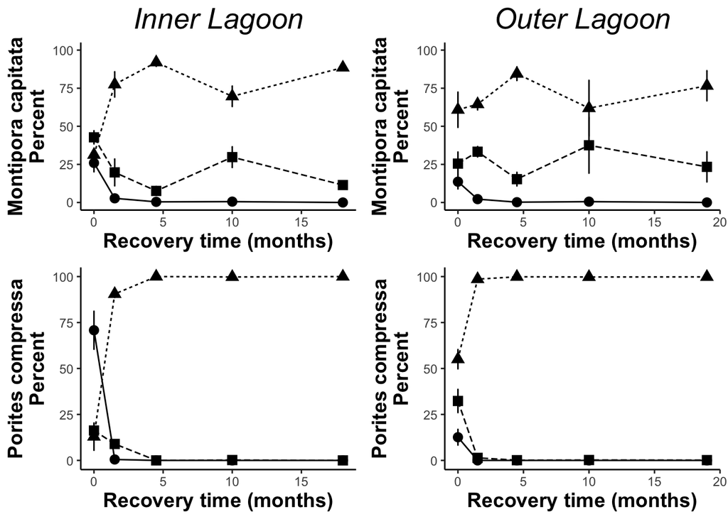

```r
grid.arrange(McapInner, McapOuter, PcompInner,PcompOuter, nrow = 2)
```

```r
#Sum: White (W) + Pale (P)

rData2<-rData1[!(rData1$Bleaching_status=="Healthy"),]    # Remove Healthy
rData2$code<-paste0(rData2$Species, rData2$Month, rData2$MonthFactor, rData2$Depth, rData2$Reef, rData2$Rep)#create a code for groups by Species, Month, Depth, Reef, Rep
rData3<-rData2 %>% group_by(code) %>%summarise(sum=sum(Percent))# Group Data: combine P and B %s

# Match this back with data cols you want
rData3$Species<-rData2$Species[match(rData3$code, rData2$code)]
rData3$Month<-rData2$Month[match(rData3$code, rData2$code)]
rData3$Depth<-rData2$Depth[match(rData3$code, rData2$code)]
rData3$Reef<-rData2$Reef[match(rData3$code, rData2$code)]
rData3$Rep<-rData2$Rep[match(rData3$code, rData2$code)]
rData3$MonthFactor<-rData2$MonthFactor[match(rData3$code, rData2$code)]
rData3<-rData3[,c(1,3,5:8,2)]
rData3$Depth<-as.factor(rData3$Depth)
rData3$Rep<-as.factor(rData3$Rep)
```

```r
#Benthic transect df setup:

ccData<-read.csv("data/Benthic_Transect_Coral_Cover.csv", header=T)
ccData$MonthFactor<-ccData$Month
ccData$MonthFactor[ccData$MonthFactor=="18"] <-"1819" #combine months 18 and 19
ccData$MonthFactor[ccData$MonthFactor=="19"] <-"1819"
ccData$MonthFactor <- factor(ccData$MonthFactor, levels=c("0", "1.5", "4.5","10","1819"))
#specify order
ccData$Reef<-as.factor(ccData$Reef)
ccData$Depth<-as.factor(ccData$Depth)

# calc average  bleaching rate/month in %  per grouping
ccMeans <- ddply(ccData, c("Reef",  "Month"), summarise,
                   N    = length(CoralCover[!is.na(CoralCover)]), #calculate the length of the data frame, excluding NA’s *this part is important*
                   mean = mean(CoralCover, na.rm=TRUE), #calculate mean of response variable, removing NA's
                   sd   = sd(CoralCover, na.rm=TRUE), #calculate standard deviation
                   se   = sd / sqrt(N), #calculate standard error
                   max = max(CoralCover, na.rm=TRUE) #calculate max
)
```

# Supplementary Table 1

Linear model summary table of the effect of lagoon on coral cover over the duration of the study (`% Coral Cover~Lagoon*Month+(1|Depth)`). Bold indicates statistical significance. Data collected by benthic transects.

```r
CoralCoverMod<-lmer(CoralCover~Reef*MonthFactor+(1|Depth), ccData)
anova(CoralCoverMod, type=2)
```

```
## Type II Analysis of Variance Table with Satterthwaite's method
##                   Sum Sq Mean Sq NumDF DenDF  F value    Pr(>F)
## Reef             17037.8 17037.8     1    30 187.0920 1.982e-14 ***
## MonthFactor        299.5    74.9     4    30   0.8221   0.52142
## Reef:MonthFactor   781.3   195.3     4    30   2.1448   0.09968 .
## ---
## Signif. codes:  0 '***' 0.001 '**' 0.01 '*' 0.05 '.' 0.1 ' ' 1
```

Tukey post hoc test

```r
 emm = emmeans(CoralCoverMod, ~ Reef, adjust="tukey")

    pairs(emm)
```

[output not shown]

# Supplementary Table 2

BLinear mixed effects model summary table of the effect of lagoon and recovery month on bleaching prevalence (white + pale corals) (`Bleaching Prevalence~Lagoon*Month*Species+(1|Depth)`). Bold indicates statistical significance. Data collected by benthic transects.

```r
#fullmodel, df=rData3
Prev_transect_full<-lmer(sum~Reef*MonthFactor*Species+(1|Depth), data=rData3)
```

```
## boundary (singular) fit: see ?isSingular
```

```r
anova(Prev_transect_full, type=2)
```

```
## Type II Analysis of Variance Table with Satterthwaite's method
##                           Sum Sq Mean Sq NumDF DenDF F value    Pr(>F)
## Reef                       309.0   309.0     1    60  1.9141   0.17164
## MonthFactor              30749.1  7687.3     4    60 47.6254 < 2.2e-16 ***
## Species                   4444.4  4444.4     1    60 27.5345 2.124e-06 ***
## Reef:MonthFactor          5124.2  1281.1     4    60  7.9366 3.334e-05 ***
## Reef:Species               732.9   732.9     1    60  4.5404   0.03721 *
## MonthFactor:Species       4736.1  1184.0     4    60  7.3354 7.054e-05 ***
## Reef:MonthFactor:Species   122.5    30.6     4    60  0.1898   0.94285
## ---
## Signif. codes:  0 '***' 0.001 '**' 0.01 '*' 0.05 '.' 0.1 ' ' 1
```

Tukey post hoc test

```r
 emm = emmeans(Prev_transect_full, ~ Reef*MonthFactor, adjust="tukey")

      pairs(emm)
    emm = emmeans(Prev_transect_full, ~ Species*MonthFactor, adjust="tukey")

    pairs(emm)
        cld(emm)
```

[output not shown]

# Supplementary Table 3

Linear mixed effects model summary table of the effect of lagoon, coral species and recovery time point on prevalence of severely bleached (white) corals (`Bleaching Severity~Species*Lagoon*Month+(1|Depth)`). Bold indicates statistical significance. Data collected by benthic transects. Bold indicates statistical significance. Data collected by benthic transects.

```r
#bleached
prevWhite<-subset(rData1, Bleaching_status=="Bleached")

WhiteMod<-lmer(Percent~Species*Reef*MonthFactor+(1|Depth),prevWhite)
```

```
## boundary (singular) fit: see ?isSingular
```

```r
anova(WhiteMod, type=2)
```

```
## Type II Analysis of Variance Table with Satterthwaite's method
##                           Sum Sq Mean Sq NumDF DenDF F value    Pr(>F)
## Species                    283.4  283.45     1    60  7.6521  0.007526 **
## Reef                      1030.7 1030.71     1    60 27.8253 1.917e-06 ***
## MonthFactor              11774.2 2943.55     4    60 79.4648 < 2.2e-16 ***
## Species:Reef               416.3  416.27     1    60 11.2377  0.001392 **
## Species:MonthFactor       1658.1  414.52     4    60 11.1905 7.566e-07 ***
## Reef:MonthFactor          3944.7  986.17     4    60 26.6228 1.018e-12 ***
## Species:Reef:MonthFactor  1687.5  421.89     4    60 11.3894 6.087e-07 ***
## ---
## Signif. codes:  0 '***' 0.001 '**' 0.01 '*' 0.05 '.' 0.1 ' ' 1
```

Tukey post hoc test

```r
 emm = emmeans(WhiteMod, ~ Reef, adjust="tukey")
    cld(emm)
  #conduct Tukey post hoc test
    emm = emmeans(WhiteMod, ~ Reef*Species*MonthFactor, adjust="tukey")
    cld(emm)
    pairs(emm)
```

[output not shown]

# Supplementary Table 4

Linear mixed effects model summary table for the effect of lagoon, coral species, and recovery month on bleaching severity (proportion of completely white corals out of the all affected corals) (`Bleaching Severity~Species*Lagoon*Month+(1|Depth)`). Bold indicates statistical significance. Data collected by benthic transects.

```r
rData4<-rData2 #make a copy of rData2
rData4$Depth<-as.factor(rData4$Depth)
rData4$Rep<-as.factor(rData4$Rep)

rData4$sum<-rData3$sum[match(rData4$code, rData3$code)] # add the sum row by code to get sum of W+P
rData4$newPer<-rData4$Percent/rData4$sum # Make new row of new percents which is W%/(W%+P%)
rData4<-subset(rData4, Bleaching_status=="Bleached") # get rid of Pale

#full model
SeverityMod<-lmer(newPer~Species*Reef*MonthFactor+(1|Depth),rData4)
```

```
## fixed-effect model matrix is rank deficient so dropping 2 columns / coefficients
```

```
## boundary (singular) fit: see ?isSingular
```

```r
anova(SeverityMod, type="2")
```

```
## Type II Analysis of Variance Table with Satterthwaite's method
##                           Sum Sq Mean Sq NumDF DenDF F value    Pr(>F)
## Species                  0.00965 0.00965     1    43  0.7755 0.3834183
## Reef                     0.19990 0.19990     1    43 16.0624 0.0002393 ***
## MonthFactor              1.67394 0.41848     4    43 33.6254  9.99e-13 ***
## Species:Reef             0.07069 0.07069     1    43  5.6796 0.0216512 *
## Species:MonthFactor      0.16960 0.04240     4    43  3.4068 0.0165986 *
## Reef:MonthFactor         0.11057 0.02764     4    43  2.2210 0.0825494 .
## Species:Reef:MonthFactor 0.15839 0.07919     2    43  6.3633 0.0037952 **
## ---
## Signif. codes:  0 '***' 0.001 '**' 0.01 '*' 0.05 '.' 0.1 ' ' 1
```

Tukey post hoc test

```r
 emm = emmeans(SeverityMod, ~ Species*MonthFactor*Reef, adjust="tukey")

    cld(emm)
    pairs(emm)
 #conduct Tukey post hoc test
    emm = emmeans(SeverityMod, ~ Reef*Species*MonthFactor, adjust="tukey")
        pairs(emm)
```

[output not shown]